# Using Normal Distribution and Z Score

# Table of Contents

## 1. Using Normal Distribution

### 1.1 Using Empirical Rule (68 - 95 - 99.7%)

This is simplest form of solving probability for a given problem. These we could typically do without calculator, as they are very straight forward.

It simply means, we assume that 68% of the data is within 1 standard deviation, 95% is within 2 standard deviation, 99.7% is within 3 standard deviations.

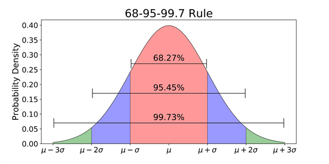

**Example:**

**Given:**

$ \mu = 3.1 \\ \sigma = 0.6 \\ p(X < 2.5) = ? $

**Approach:**

Let us check if 2.5 is a multiple of SD from mean,..  
$ \mu + a\sigma = 2.5 \\ 3.1 + a(0.6) = 2.5 \\ a(0.6) = -0.6 \\ a = -1 $

This exact multiple is an indication we could write away use empirical rule without having to integrate anything. Sometimes questions explicitly state, and sometimes not, so we could check and apply accordingly. If they say "without using calculator", that could be a hint as well.

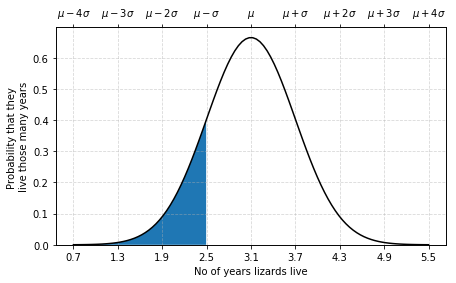

```python
import matplotlib.pyplot as plt
from normalviz import draw_normal

mu = 3.1
sigma = 0.6

# plot
fig, ax = plt.subplots(1,1, figsize=(7,4))
draw_normal(ax, mu, sigma, 'x<2.5')  # question is x less than 2.5 years
ax.set_xlabel('No of years lizards live')
ax.set_ylabel('Probability that they \nlive those many years')
plt.show()
```

As you can see above, we just need to find the area of shaded area, and 2.5 is exactly at $\mu-\sigma$.

The total area of curve = 100% (as total probability is always 1)

Area from $\mu$ to $\infty$ = $p(X>\mu)$ = 50%  
Area between $(\mu-\sigma)$ and $(\mu + \sigma)$ = $p\Big((\mu-\sigma)<X<(\mu+\sigma)\Big)$ = 68% $\ \ \because$ emperical rule

Thus,  
Area between $(\mu-\sigma)$ and $\mu$ is $p\Big((\mu-\sigma)<X<\mu\Big)$ = $\dfrac {68}{2} = 34\%$

Now, we could easily calculate area of our interest as  
$ p\Big( X < (\mu-\sigma) \Big) = 1 - \Bigg(p\Big((\mu-\sigma)<X<\mu\Big) + p(X>\mu)\Bigg) = 1 - \Big( 0.34 + 0.5 \Big) = 0.16 $

Thus solution is 16%

### 1.2 Using Integrals

What if the number in question is not multiple of standard deviation?

**Example:**

> A set of middle school student heights are normally distributed with a mean of **150 cm** and standard deviation of **20 cm**. Darnell is a middle school student with a height of **161.4 cm**. What proportion of student heights are lower than Darnell's height? Give your answer correct to four decimal places.

**Given:** $ \mu = 150 \ \ \ \ \sigma = 20 \ \ \ \ p(X<161.4)=? $

**Approach:**  
$ \mu + a\sigma = 161.4 \\ 150 + a(20) = 161.4 \\ a(20) = 161.4 - 150 = 11.4 \\ a = \frac {11.4}{20} = 0.57 $

So Darnell is $0.57\sigma$ away from the mean, not exact multiple of sigma.

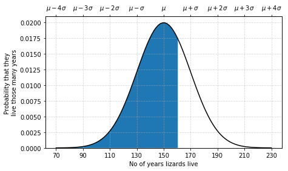

```python
mu = 150
sigma = 20

# plot
fig, ax = plt.subplots(1,1, figsize=(7,4))
draw_normal(ax, mu, sigma, 'x<161.4')  # question is x less than 2.5 years
ax.set_xlabel('No of years lizards live')
ax.set_ylabel('Probability that they \nlive those many years')
plt.show()
```

Remember, a normal function is given by,

$ p(X) = \dfrac {1}{\sigma\sqrt{2\pi}}e^{-\dfrac{1}{2} \Big( \dfrac{X-\mu}{\sigma} \Big)^2 } $

So we need to integrate to calculate the area of interest as shown above.

$ \displaystyle { p(X<161.4) = \int_{-\infty}^{161.4} \dfrac {1}{\sigma\sqrt{2\pi}}e^{-\dfrac{1}{2} \Big( \dfrac{X-\mu}{\sigma} \Big)^2 } dx \ = \dfrac {1}{\sigma\sqrt{2\pi}} \int_{-\infty}^{161.4} e^{-\dfrac{1}{2} \Big( \dfrac{X-\mu}{\sigma} \Big)^2 } dx \ = \dfrac {1}{\sigma\sqrt{2\pi}} \int_{-\infty}^{161.4} e^{-\dfrac{1}{2} \Big( \dfrac{X-150}{20} \Big)^2 } dx \\ \\ } $

This integration is highly complicated, and thus we have something called z-score, but before that, we will leave the hardway of integrating to python and see what it churns out.

```python
from scipy.integrate import quad
import numpy as np
from math import sqrt, pi

def pdf(x):
    C = 1/(sigma*sqrt(2*pi))
    E = -(((x-mu)/sigma)**2)/2
    G = C*np.exp(E)
    return G

xstart = mu - 4*sigma
xend = mu + 4*sigma
x = np.linspace(xstart, xend, 100)

# Integrate PDF from -inf to x
result, _ = quad(pdf,  -np.inf, 161.4, limit = 1000)
print(round(result,4))
```

```
0.7157
```

Cool! The answer is $\color {blue}{0.7157}$ or 71.57%

## 2. Z Score

### 2.1 Z Score to easily evaluate area

Earlier days, one has to painfully integrate the above example, and that too for every such problem! If you remember, our normal approximation function is a standard guassian function shifted by mean and scaled by sigma as required to fit our probability distribution accordingly.

This means, we could transform every such normal distribution back to the standard normal distribution. If we have all possible areas calculated (well, as much as possible), we could simply refer to those values, because the areas would remain the same.

The area information we have for standard normal deviation is called Z table. Note that, when we **shift** the curve, we also need to have the area of interest shifted accordingly. This is where, we calculate something called Z score which is a standard value for how far our question of interest, is from the mean. You will understand that in a minute.

This is our current normal approximation function.

$ p(X) = \dfrac {1}{\sigma\sqrt{2\pi}}e^{-\dfrac{1}{2} \Big( \dfrac{X-\mu}{\sigma} \Big)^2 } $

Let $Z = \dfrac {X-\mu}{\sigma}$, then

$ p(Z) = \dfrac {1}{\sigma\sqrt{2\pi}}e^{-\dfrac{1}{2} \Big( Z \Big)^2 } $

When, $X = \mu$, $Z = \dfrac {X-\mu}{\sigma} = 0$  
When, $X = \mu + \sigma$, $Z = \dfrac {X-\mu}{\sigma} = \dfrac {\mu + \sigma - \mu}{\sigma} = 1$

Thus, on Z scale, $\mu = 0$ and $\sigma = 1$. One unit on Z scale will indicate $1\sigma$ on X scale. Any probability distribution could be **transformed** to this **standard** form, thus facilitating easy area calculation.

Below is how, our standard function looks like.

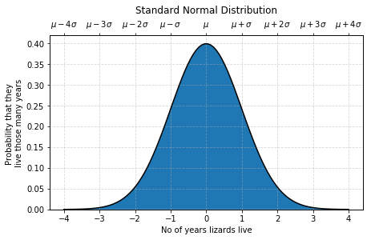

```python
def normal_pdf(z):
    C = 1/(sqrt(2*pi))
    E = -(z**2)/2
    G = C*np.exp(E)
    return G

mu = 0
sigma = 1
zstart = mu - 4*sigma
zend = mu + 4*sigma
z = np.linspace(zstart, zend, 100)

# plot
fig, ax = plt.subplots(1,1, figsize=(7,4))
draw_normal(ax, mu, sigma)
ax.set_xlabel('No of years lizards live')
ax.set_ylabel('Probability that they \nlive those many years')
plt.title('Standard Normal Distribution',y=1.1)
plt.show()
```

Oh Wait! What about our area of interest? We have not done that yet.

When $X = 161.4 \ \ Z = \dfrac {X-\mu}{\sigma} = \dfrac {161.4-150}{20} = 0.57$

Applying that..

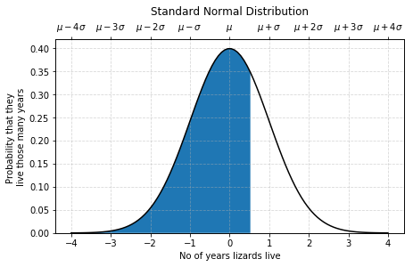

```python
# plot
fig, ax = plt.subplots(1,1, figsize=(7,4))
draw_normal(ax, mu, sigma, 'x<0.57')   # for this function, x is x. mu and sigma takes care of the shift
ax.set_xlabel('No of years lizards live')
ax.set_ylabel('Probability that they \nlive those many years')
plt.title('Standard Normal Distribution',y=1.1)
plt.show()
```

Now we just have to find out area as shown above. That is, $p(Z<=0.57)$

Let us check the Z table. The value in the table always indicate the area below the limit value we are looking for. Here, we would get area below $Z=0.57$

For brevity, I have only shown a part of table, but such tables can be easily found online like one [here](http://www.z-table.com/)

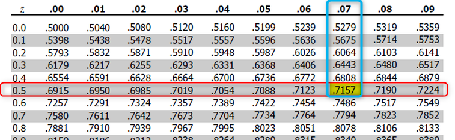

The answer is 0.7157 again!! This is exactly the same we got via integral earlier!

So that is all, the use of Z-scores? No, it could also be useful to compare different probability distributions.

By the way, the value we arrived at, Z = 0.57 is called Z-score, or Z-score of Darnell.

Given the mean $\mu$, variance $\sigma$ and point of interest X, the Z score can be calculated as $Z=\dfrac{X-\mu}{\sigma}$

### 2.2 Z Score to Compare

Example:

> Juwan took 2 exams. He scored 172 on the LSAT and 37 on the MCAT. Which exam did he do relatively better on? Given below are the probability distributions for LSAT and MCAT.

| Exam | Mean | Standard deviation |
| --- | --- | --- |
| LSAT | 151 | 10 |
| MCAT | 25.1 | 6.4 |

We are not asked, proportion of students below or above Juwan's LSAT score or MCAT score. We are asked to compare Juwan's own scores. But both exams are different.

The key idea is this:

> By **standardizing** Juwan's LSAT and MCAT score to standard normal distribution, we are bringing down different distributions to same scale. Now we could compare his both Z-scores.

And note, we do not even have to calculate area for this problem. However, even if needed, its not a big deal as we now know how to calculate area from previous examples.

**Given:** $ \mu_x = 151, \ \sigma_x = 10 \\ \mu_y = 25.1, \ \sigma_y = 6.4 \\ X = 172, Y = 37 $

**Approach: Calculate Z scores**  
$ Z_x = \dfrac {172-151}{10} = 2.1 \\ Z_y = \dfrac {37-25.1}{6.4} = 1.86 \\ $

**Ans:**  
$Z_x > Z_y$, so Juwan did LSAT better.

> Also note, as long as we have a mean and standard deviation, this transformation to Z score will be possible and valid. The distributions need not be normal always.